# Group_Proj

Group_1

2022/6/26

# 导入数据并进行数据预处理

```r
review <- read.csv(".\\review.csv", stringsAsFactors = FALSE, header = TRUE)
```

首先我们筛选出UTF-8格式且为英文的评论，并根据slide5生成对应的变量：

```r
review <- review %>%
  # 筛选需要的评论
  mutate(
    ReviewText = iconv(ReviewText,"UTF-8", "UTF-8",sub=""),
    language = textcat(ReviewText)
  ) %>%
  filter(!is.na(ReviewText)) %>%
  filter(language == "english") %>%
  filter(ReviewID!="272094473") %>%
  # 生成并检查Obs_Avg_Rating
  mutate(RatingDate = as.Date(RatingDate)) %>%
  group_by(HotelID) %>%
  arrange(RatingDate) %>%
  mutate(
    Rating_Deviation = abs(AvgRatingStarsThisUser - Obs_Avg_Rating),
    test_Obs_Avg_Rating = cummean(AvgRatingStarsThisUser),
    test_Obs_Avg_Rating = ifelse(
      is.na(lag(test_Obs_Avg_Rating)), 0, lag(test_Obs_Avg_Rating)
    ),
    test_Obs_Avg_Rating_2 = ifelse(
      test_Obs_Avg_Rating == floor(test_Obs_Avg_Rating), test_Obs_Avg_Rating, ifelse(
        (test_Obs_Avg_Rating - floor(test_Obs_Avg_Rating)) >= 0.75,
        floor(test_Obs_Avg_Rating) + 1, ifelse(
          (test_Obs_Avg_Rating - floor(test_Obs_Avg_Rating)) < 0.25,
          floor(test_Obs_Avg_Rating), floor(test_Obs_Avg_Rating) +0.5
        )
      )
    ),
    test_Rating_Deviation = abs(AvgRatingStarsThisUser - test_Obs_Avg_Rating_2),
    Check = ifelse(Rating_Deviation == test_Rating_Deviation, T, F)
  ) %>%
  ungroup() %>%
  # 对Age与Gender预处理
  mutate(
    Age = ifelse(Age=="|"|Age=="Another", NA, Age),
    Gender = str_to_lower(Gender)
  ) %>%
  # 生成对应的变量
  mutate(
    Not_Disclosure = ifelse(is.na(Gender)|is.na(Age), T, F),
    Gender = ifelse(is.na(Gender), "NA", Gender),
    women = ifelse(Gender == "female" & Not_Disclosure==F, T, F),
    Age = ifelse(is.na(Age),"NA", Age),
    YoungAge = ifelse(Age %in% c("25-34", "18-24", "13-17") & Not_Disclosure==F, T, F),
    MidAge = ifelse(Age == "35-49" & Not_Disclosure==F, T, F),
    OldAge = ifelse(Age %in% c("50-64", "65+") & Not_Disclosure==F, T, F),
    WC = str_count(ReviewText,boundary("word")), # 思考数字是否需要保留
    # WC = str_count(str_remove_all(ReviewText,"\\d{0,}"),boundary("word")),
    HotelID = as.factor(HotelID),
    year = as.factor(str_extract(year_month, "\\d{2}"))
  )
review %>%
  head(10)
```

```
## # A tibble: 10 × 39
##    HotelID ReviewID Location_Rating Service_Rating Rooms_Rating Sleep_Quality_R…
##    <fct>      <int>           <int>          <int>        <int>            <int>
##  1 73763     850442              NA             NA           NA               NA
##  2 73470    1137122              NA             NA           NA               NA
##  3 73250    1154459              NA             NA           NA               NA
##  4 98419    1273215              NA             NA           NA               NA
##  5 98419    1369717              NA             NA           NA               NA
##  6 98426    1627225              NA             NA           NA               NA
##  7 98436    1646088              NA              3            1               NA
##  8 73242    1702475              NA             NA           NA               NA
##  9 98436    1726816              NA             NA           NA               NA
## 10 73242    1734964              NA              3            2               NA
## # … with 33 more variables: Value_Raing <int>, Cleanliness_Raing <int>,
## #   Property <chr>, FoodDrink <chr>, InYourRoom <chr>, Internet <chr>,
## #   PriceRange <chr>, X <int>, RatingDate <date>, ReviewText <chr>,
## #   AvgRatingStarsThisUser <int>, NumHelpful <int>, StarClass <dbl>,
## #   Obs_Avg_Rating <dbl>, Gender <chr>, Age <chr>, Contributions <int>,
## #   Cities_Visited <int>, year_month <chr>, ElapsedDays <int>, language <chr>,
## #   Rating_Deviation <dbl>, test_Obs_Avg_Rating <dbl>, …
```

# 可视化探究——基本信息展示

**1. 评论中单词个数的分布**

```r
summary(review$WC)
```

```
##    Min. 1st Qu.  Median    Mean 3rd Qu.    Max.
##     4.0    46.0    69.0   101.6   123.0  1702.0
```

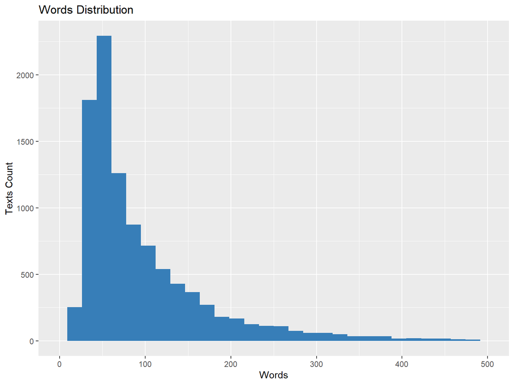

```r
review %>%
  ggplot(aes(x = WC)) +
  #geom_freqpoly(binwidth = 5) +
  geom_histogram(fill = brewer.pal(6, "Set1")[2]) +
  xlim(0,500) +
  labs(title = "Words Distribution", x = "Words", y = "Texts Count")
```

**2. 不同年龄段的人赋予酒店的评分特征**

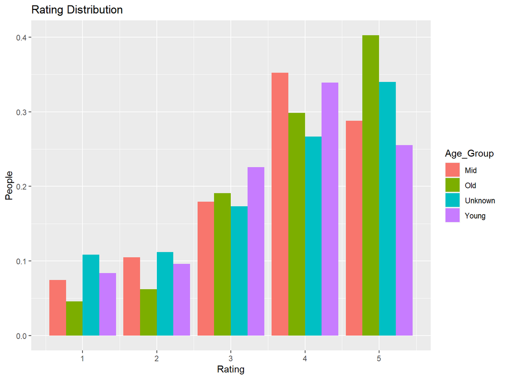

```r
review_Age_Group <- review %>%
  mutate(
    Age_Group = ifelse(YoungAge == T, "Young", ifelse(
      OldAge == T, "Old", ifelse(
        MidAge == T, "Mid", "Unknown")
      )
     )
    )

review_Age_Group %>%
  #filter(Age_Group!="Unknown") %>%
  ggplot(aes(x = AvgRatingStarsThisUser,y=..prop.., fill = Age_Group)) +
    geom_bar(position = position_dodge()) +
    labs(title = "Rating Distribution", x = "Rating", y = "People")
```

Comment：可以看到，老年人组打高分的比例更高，而我们有理由怀疑不展示自己信息的人给出评分会更低（根据文献）

**3. 当前用户的评分与照往期观测值的影响**

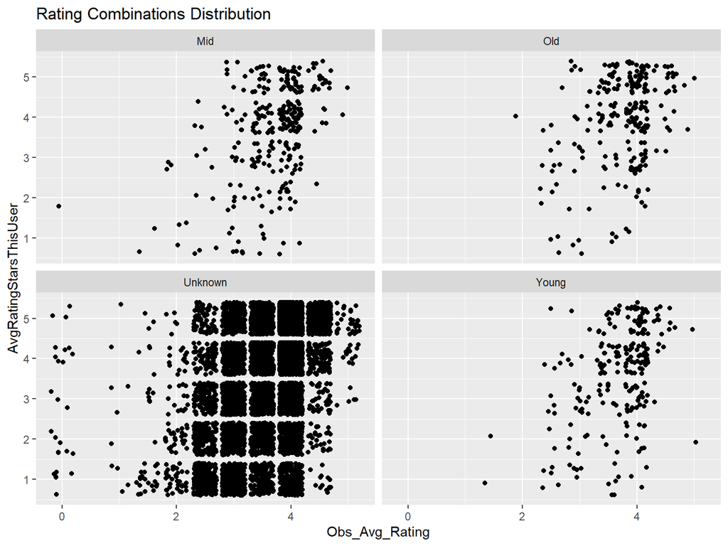

```r
review_Age_Group %>%
  ggplot(aes(x = Obs_Avg_Rating, y = AvgRatingStarsThisUser)) +
  geom_jitter() +
  facet_wrap(~Age_Group, nrow = 2) +
  labs(title = "Rating Combinations Distribution")
```

# 对文本进行处理

**1.文本预处理**

首先得到基础的语料库，然后进行标准化操作，并生成DF：

```r
# 方法：参考quanteda资料，使用corpus的方法生成，更有利于处理（ref1:https://quanteda.io/articles/pkgdown/quickstart_cn.html；ref2:https://zhuanlan.zhihu.com/p/439456688）
# 生成语料库
review_corpus <- corpus(review$ReviewText)
# 标准化语料库，此语料库课用于可视化展示，若不需要可以在下面生成DTM一起解决
review_tokens <- review_corpus %>%
  tokens(
    remove_punct = T,
    remove_symbols = T,
    remove_numbers = T,
    remove_separators = T
  )
# 生成DTM的dataframe
review_DTM <- review_tokens %>%
  dfm(
    # set lowercasing
    tolower = T,
    # stemming to TRUE
    stem = T,
    # provide the stopwords for deletion
    remove = stopwords("english")
  ) %>%
  as.matrix() %>%
  as.data.frame()
```

**手动计算词频**

```r
doc_id <- rownames(review_DTM)

WC_tokens <- summary(review_tokens) %>%
  as.data.frame() %>%
  dplyr::select(Freq) %>%
  transmute(WC = Freq) %>%
  slice(1:10044) %>%
  mutate(doc = doc_id)


review_DTM_TF <- review_DTM %>%
  as_tibble() %>%
  mutate(doc = doc_id) %>%
  pivot_longer(cols = !c(doc),
               names_to = "term",
               values_to = "freq") %>%
  left_join(WC_tokens, by = "doc") %>%
  mutate(TermFreq = freq/as.numeric(WC))
```

**2.对anxious和angry的分析**

基于之前构建的DTM来做分析：

```r
# 构建对应的词典与DTM
# angry
Angry_Dictionary <- c("abuse","aggress","anger","angry","annoy","argh","assault",
                      "asshole","attack","battl","bastard","beaten","bitch","bitter",
                      "blam","bother","cheat","confront","contempt","crap","critical",
                      "cruel","damn","destroy","destruct","dumb","dummy","enemy","envy",
                      "fiery","fight","foe","fuck","greed","hate","hell","idiot","insult",
                      "jealous","jerk","kill","lie","mad","mock","offence","pest","protest",
                      "rage","rude","shit","snob","stupid","suck","temper","trick","ugly",
                      "war","wick","yell")

Angry_DTM <- review_DTM[(colnames(review_DTM) %in% Angry_Dictionary)]
Angry_DTM %>%
  head(10)
```

```
##        fight yell bother hell trick suck battl annoy mad rude crap attack lie
## text1      0    0      0    0     0    0     0     0   0    0    0      0   0
## text2      0    0      0    0     0    0     0     0   0    0    0      0   0
## text3      0    0      0    0     0    0     0     0   0    0    0      0   0
## text4      0    0      0    0     0    0     0     0   0    0    0      0   0
## text5      0    0      0    0     0    0     0     0   0    0    0      0   0
## text6      0    0      0    0     0    0     0     0   0    0    0      0   0
## text7      2    1      1    0     0    0     0     0   0    0    0      0   0
## text8      0    0      0    0     0    0     0     0   0    0    0      0   0
## text9      0    0      0    0     0    0     0     0   0    0    0      0   0
## text10     0    0      0    0     0    0     0     0   0    0    0      0   0
##        protest assault insult hate dumb bitter idiot stupid war snob kill
## text1        0       0      0    0    0      0     0      0   0    0    0
## text2        0       0      0    0    0      0     0      0   0    0    0
## text3        0       0      0    0    0      0     0      0   0    0    0
## text4        0       0      0    0    0      0     0      0   0    0    0
## text5        0       0      0    0    0      0     0      0   0    0    0
## text6        0       0      0    0    0      0     0      0   0    0    0
## text7        0       0      0    0    0      0     0      0   0    0    0
## text8        0       0      0    0    0      0     0      0   0    0    0
## text9        0       0      0    0    0      0     0      0   0    0    0
## text10       0       0      0    0    0      0     0      0   0    0    0
##        confront anger temper beaten mock aggress destroy damn greed pest jerk
## text1         0     0      0      0    0       0       0    0     0    0    0
## text2         0     0      0      0    0       0       0    0     0    0    0
## text3         0     0      0      0    0       0       0    0     0    0    0
## text4         0     0      0      0    0       0       0    0     0    0    0
## text5         0     0      0      0    0       0       0    0     0    0    0
## text6         0     0      0      0    0       0       0    0     0    0    0
## text7         0     0      0      0    0       0       0    0     0    0    0
## text8         0     0      0      0    0       0       0    0     0    0    0
## text9         0     0      0      0    0       0       0    0     0    0    0
## text10        0     0      0      0    0       0       0    0     0    0    0
##        cheat contempt foe
## text1      0        0   0
## text2      0        0   0
## text3      0        0   0
## text4      0        0   0
## text5      0        0   0
## text6      0        0   0
## text7      0        0   0
## text8      0        0   0
## text9      0        0   0
## text10     0        0   0
```

```r
# anxious
Anxious_Dictionary <- c("afarid","alarm","anxiety","anxious","asham","avoid","awkward",
                        "confuse","desperat","discomfort","distress","disturb","doubt",
                        "embarrass","fear","frantic","guilt","horrible","humiliat",
                        "indecis","inhibit","nervous","obsess","overwhelm","panic",
                        "pressur","repress","rigid","risk","scare","shake","shy","tense",
                        "timid","uncertain","unsure","upset","worry")

Anxious_DTM <- review_DTM[(colnames(review_DTM) %in% Anxious_Dictionary)]

# 在review中生成angry和anxious变量
review <- review %>%
  mutate(
    angry = 100*rowSums(Angry_DTM)/WC,
    anxious = 100*rowSums(Anxious_DTM)/WC
    )
Anxious_DTM %>%
  head(10)
```

```
##        overwhelm avoid distress pressur scare disturb upset alarm doubt awkward
## text1          0     0        0       0     0       0     0     0     0       0
## text2          0     0        0       0     0       0     0     0     0       0
## text3          0     0        0       0     0       0     0     0     0       0
## text4          0     0        0       0     0       0     0     0     0       0
## text5          0     0        0       0     0       0     0     0     0       0
## text6          0     0        0       0     0       0     0     0     0       0
## text7          0     0        0       0     0       0     0     0     0       0
## text8          0     0        0       0     0       0     0     0     0       0
## text9          0     0        0       0     0       0     0     0     0       0
## text10         0     0        0       0     0       0     0     0     0       0
##        anxious risk nervous panic fear shake uncertain frantic asham discomfort
## text1        0    0       0     0    0     0         0       0     0          0
## text2        0    0       0     0    0     0         0       0     0          0
## text3        0    0       0     0    0     0         0       0     0          0
## text4        0    0       0     0    0     0         0       0     0          0
## text5        0    0       0     0    0     0         0       0     0          0
## text6        0    0       0     0    0     0         0       0     0          0
## text7        0    0       0     0    0     0         0       0     0          0
## text8        0    0       0     0    0     0         0       0     0          0
## text9        0    0       0     0    0     0         0       0     0          0
## text10       0    0       0     0    0     0         0       0     0          0
##        embarrass
## text1          0
## text2          0
## text3          0
## text4          0
## text5          0
## text6          0
## text7          0
## text8          0
## text9          0
## text10         0
```

# 可读性分析与情感分析

先按照slide上面生成衡量可读性的变量和情感的变量，其中情感分析使用的是syuzhet包的函数

```r
review <- review %>%
  mutate(
    readability = textstat_readability(review_corpus, measure = "Flesch.Kincaid")$Flesch.Kincaid,
    sentiment = get_sentiment(review$ReviewText, method = "nrc")
  )
```

使用quanteda.sentiment生成情感分析的变量。由于两种函数所包含的共同词典仅有nrc词典，所以均采用nrc词典进行情感提取

```r
review <- review %>%
  mutate(
    sentiment_test = as_tibble(textstat_polarity(review_corpus, dictionary = data_dictionary_NRC))$sentiment
  )
review %>%
  head(10)
```

```
## # A tibble: 10 × 44
##    HotelID ReviewID Location_Rating Service_Rating Rooms_Rating Sleep_Quality_R…
##    <fct>      <int>           <int>          <int>        <int>            <int>
##  1 73763     850442              NA             NA           NA               NA
##  2 73470    1137122              NA             NA           NA               NA
##  3 73250    1154459              NA             NA           NA               NA
##  4 98419    1273215              NA             NA           NA               NA
##  5 98419    1369717              NA             NA           NA               NA
##  6 98426    1627225              NA             NA           NA               NA
##  7 98436    1646088              NA              3            1               NA
##  8 73242    1702475              NA             NA           NA               NA
##  9 98436    1726816              NA             NA           NA               NA
## 10 73242    1734964              NA              3            2               NA
## # … with 38 more variables: Value_Raing <int>, Cleanliness_Raing <int>,
## #   Property <chr>, FoodDrink <chr>, InYourRoom <chr>, Internet <chr>,
## #   PriceRange <chr>, X <int>, RatingDate <date>, ReviewText <chr>,
## #   AvgRatingStarsThisUser <int>, NumHelpful <int>, StarClass <dbl>,
## #   Obs_Avg_Rating <dbl>, Gender <chr>, Age <chr>, Contributions <int>,
## #   Cities_Visited <int>, year_month <chr>, ElapsedDays <int>, language <chr>,
## #   Rating_Deviation <dbl>, test_Obs_Avg_Rating <dbl>, …
```

# （整理修改）可视化进一步探究——词云构建

比较老龄用户评论词云和年轻用户评论词云，观察其区别。

比较2012年之前发布的评论词云与2012年之后发布的评论词云，观察其区别。

研究不同rating的词云。

去除一些高频且无实际意义的停用词后，再回答上述问题。

```r
# 构建词云数据函数
Get_wordcloud <- function(df) {
  v_Age<-sort(colSums(df),decreasing=TRUE)
  d_Age<-data.frame(word=names(v_Age),freq=v_Age)
}

# 构建获取dtm的函数
Get_dtm_group <- function(df,stopword){

  dtm_review_Age <-corpus(df$ReviewText) %>%
    tokens(
      remove_punct = T,
      remove_symbols = T,
      remove_numbers = T,
      remove_separators = T
    )  %>%
    dfm(tolower = T) %>%
    dfm_remove(c(stopwords("en"),stopword)) %>%
    dfm_wordstem()%>%
    as.matrix() %>%
    as.data.frame()

  return(dtm_review_Age)
}
# 设定部分停用词（需要修改）
stopword_review=c("room","hotel","stay","staff","rooms")
```

**比较老龄用户评论词云和年轻用户评论词云，观察其区别。**

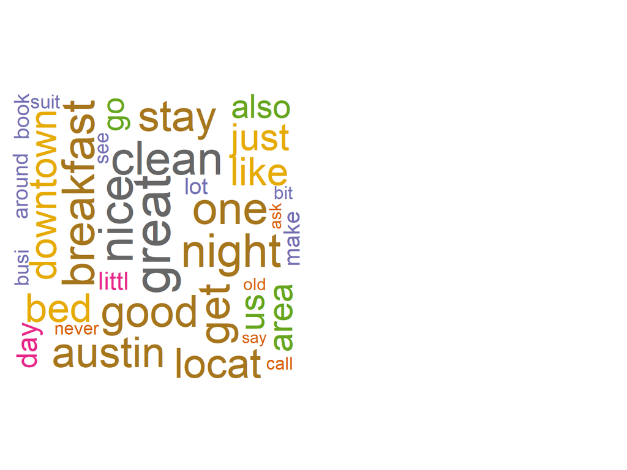

```r
# 年轻人vs老年人
#png("WC_age2.png",width = 1080,height = 720)
par(mfrow=c(1,2))#画布
review_YoungAge <- review%>%
  filter(YoungAge==T)
dtm_review_YoungAge <- Get_dtm_group(review_YoungAge, stopword_review)
wc_Y<-Get_wordcloud(dtm_review_YoungAge)

#词云
wordcloud(words=wc_Y$word,freq=wc_Y$freq,min.freq=1,max.words=100,random.order=FALSE,rot.per=0.35,colors=brewer.pal(8,"Dark2"))
```

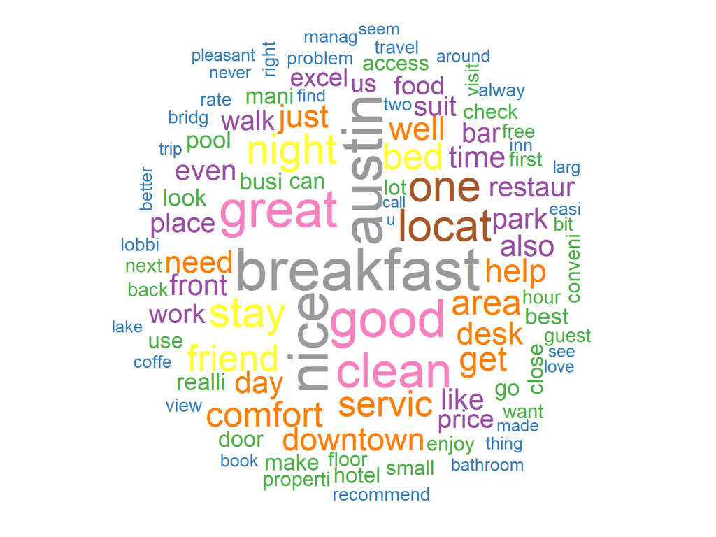

```r
review_OldAge <- review%>%
  filter(OldAge==T)
dtm_review_OldAge <- Get_dtm_group(review_OldAge, stopword_review)
wc_O <-Get_wordcloud(dtm_review_OldAge)

#词云

wordcloud(words=wc_O$word,freq=wc_O$freq,min.freq=1,max.words=100,random.order=FALSE,colors=brewer.pal(9,"Set1"))
```

**比较2012年之前发布的评论词云与2012年之后发布的评论词云，观察其区别。**

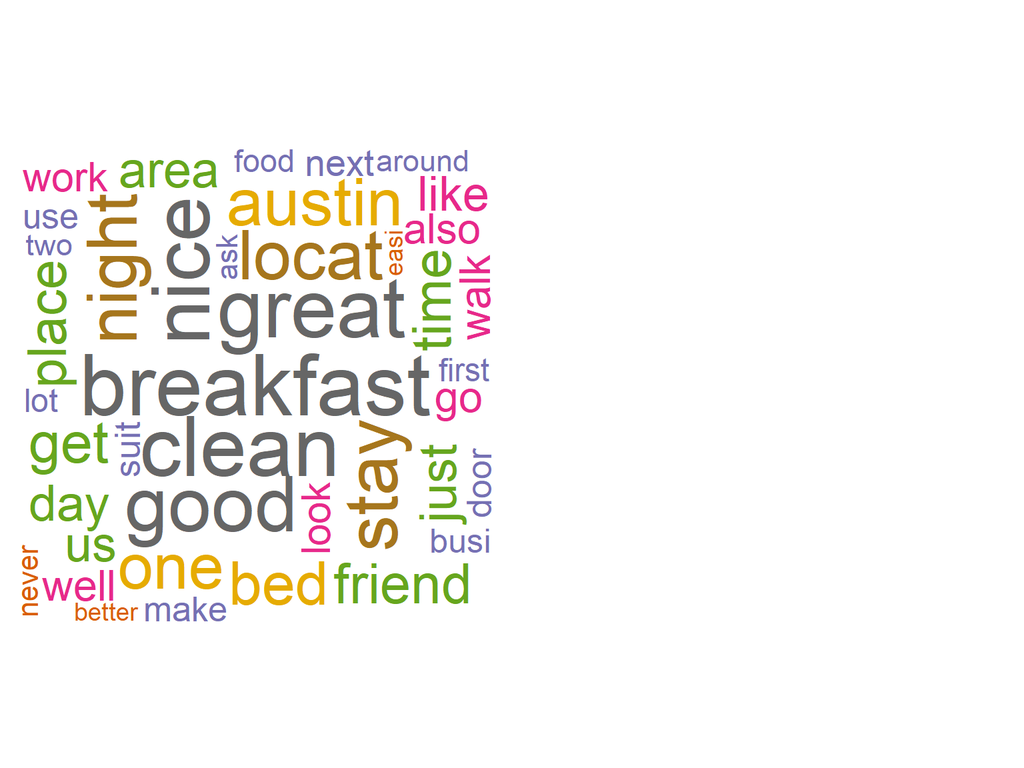

```r
# 2012年以前vs2012年以后
#png("WC_2012.png",width = 1080,height = 720)
par(mfrow=c(1,2))#画布
review_2012b<-review%>%
  filter(as.numeric(year)<=12)
dtm_review_2012b <- Get_dtm_group(review_2012b, stopword_review)
wc_b <- Get_wordcloud(dtm_review_2012b)

wordcloud(words=wc_b$word,freq=wc_b$freq,min.freq=1,max.words=100,random.order=FALSE,rot.per=0.35,colors=brewer.pal(8,"Dark2"))
```

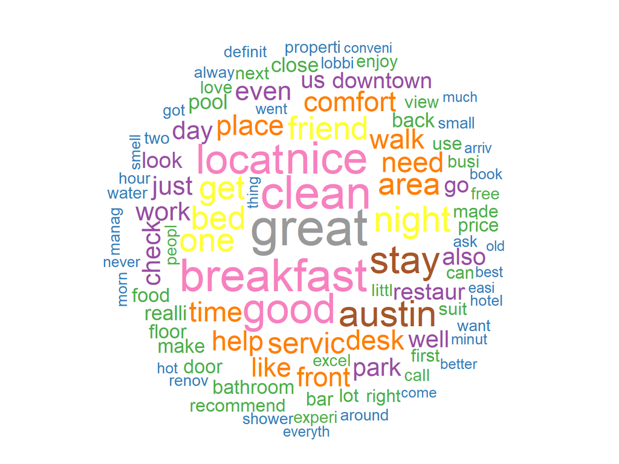

```r
review_2012a <- review%>%
  filter(as.numeric(year)>12)
dtm_review_2012a <- Get_dtm_group(review_2012a, stopword_review)
wc_a <- Get_wordcloud(dtm_review_2012a)


wordcloud(words=wc_a$word,freq=wc_a$freq,min.freq=1,max.words=100,random.order=FALSE,colors=brewer.pal(9,"Set1"))
```

```r
review_rating<-review %>%
  split(.$Obs_Avg_Rating)
png("WC_rating1.png",width = 1080,height = 1500)
par(mfrow=c(4,3))
for (n in 1:10) {
  Get_dtm_group(review_rating[[n]], stopword_review)
  wc_rating <- Get_wordcloud(dtm_review_OldAge)
  wordcloud(words=wc_rating$word,freq=wc_rating$freq,min.freq=1,max.words=100,random.order=T,colors=brewer.pal(9,"Set1"))
}
```

# 回归分析1

**注意回归分析中各项系数与老师给出的回归系数的差异，还存在许多细微的差异！**

**1. 进行五次指定的回归分析**

```r
# Regression without fixed effect
Base = glm.nb(NumHelpful~
               AvgRatingStarsThisUser +
               Rating_Deviation +
               log(WC) +
               Not_Disclosure +
               women +
               MidAge +
               OldAge,
              review,link = log)
# Regression with fixed effect
Base_FE = glm.nb(NumHelpful~
               AvgRatingStarsThisUser +
               Rating_Deviation +
               log(WC)+
               Not_Disclosure +
               women +
               MidAge +
               OldAge +
               HotelID+
               year,
             review,
             link = log)
# 加入文本变量后的回归
Text = glm.nb(NumHelpful~
               angry +
               anxious +
               readability +
               sentiment ,
             review,link = log)
# 加入固定效应后
Text_FE = glm.nb(NumHelpful~
               angry +
               anxious +
               readability +
               sentiment +
               HotelID +
               year,
             review,link = log)
# 加入控制变量后
Text_FE_Control = glm.nb(NumHelpful~
               AvgRatingStarsThisUser +
               Rating_Deviation +
               log(WC)+
               Not_Disclosure +
               women +
               MidAge +
               OldAge +
               angry +
               anxious +
               readability +
               sentiment +
               HotelID +
               year,
             review,link = log)
# 输出规范的三线表
stargazer(list(Base, Base_FE, Text, Text_FE, Text_FE_Control),type = "text", omit = c("HotelID","year"))
```

```
##
## ===========================================================================================================
##                                                        Dependent variable:
##                        ------------------------------------------------------------------------------------
##                                                             NumHelpful
##                              (1)              (2)              (3)              (4)              (5)
## -----------------------------------------------------------------------------------------------------------
## AvgRatingStarsThisUser    -0.101***        -0.175***                                          -0.184***
##                            (0.019)          (0.018)                                            (0.020)
##
## Rating_Deviation           0.296***         0.239***                                           0.238***
##                            (0.032)          (0.027)                                            (0.027)
##
## log(WC)                    0.642***         0.378***                                           0.359***
##                            (0.033)          (0.029)                                            (0.033)
##
## Not_Disclosure            -0.477***         -0.305**                                           -0.307**
##                            (0.159)          (0.126)                                            (0.126)
##
## women                       -0.232          -0.247*                                            -0.248*
##                            (0.154)          (0.127)                                            (0.127)
##
## MidAge                      -0.196           -0.228                                             -0.228
##                            (0.179)          (0.145)                                            (0.145)
##
## OldAge                     -0.377*          -0.271*                                            -0.275*
##                            (0.199)          (0.164)                                            (0.164)
##
## angry                                                        0.295***         0.230***          -0.001
##                                                              (0.071)          (0.060)          (0.064)
##
## anxious                                                      0.230***         0.200***         0.092**
##                                                              (0.059)          (0.042)          (0.043)
##
## readability                                                  0.024***         0.011***          0.001
##                                                              (0.005)          (0.004)          (0.004)
##
## sentiment                                                    0.026***         -0.0005           0.007
##                                                              (0.006)          (0.006)          (0.006)
##
## Constant                  -3.465***          -0.088         -1.351***         1.392***          -0.006
##                            (0.245)          (0.455)          (0.049)          (0.459)          (0.462)
##
## -----------------------------------------------------------------------------------------------------------
## Observations                10,044           10,044           10,044           10,044           10,044
## Log Likelihood            -7,250.801       -6,206.466       -7,581.791       -6,503.162       -6,204.329
## theta                  0.488*** (0.025) 2.201*** (0.210) 0.337*** (0.015) 1.364*** (0.104) 2.196*** (0.209)
## Akaike Inf. Crit.         14,517.600       12,508.930       15,173.580       13,096.320       12,512.660
## ===========================================================================================================
## Note:                                                                           *p<0.1; **p<0.05; ***p<0.01
```

**2. 分析不同的情感分析变量对回归结果是否有影响**

```r
# 加入文本变量后的回归
Text_Test = glm.nb(NumHelpful~
               angry +
               anxious +
               readability +
               sentiment_test,
             review,link = log)

# 加入控制变量后
Text_FE_Control_Test = glm.nb(NumHelpful~
               AvgRatingStarsThisUser +
               Rating_Deviation +
               log(WC)+
               Not_Disclosure +
               women +
               MidAge +
               OldAge +
               angry +
               anxious +
               readability +
               sentiment_test +
               HotelID +
               year,
             review,link = log)

# 输出规范的三线表
stargazer(list(Text, Text_Test, Text_FE_Control, Text_FE_Control_Test),type = "text", omit = c("HotelID","year"))
```

```
##
## ==========================================================================================
##                                                Dependent variable:
##                        -------------------------------------------------------------------
##                                                    NumHelpful
##                              (1)              (2)              (3)              (4)
## ------------------------------------------------------------------------------------------
## AvgRatingStarsThisUser                                      -0.184***        -0.176***
##                                                              (0.020)          (0.021)
##
## Rating_Deviation                                             0.238***         0.237***
##                                                              (0.027)          (0.027)
##
## log(WC)                                                      0.359***         0.377***
##                                                              (0.033)          (0.029)
##
## Not_Disclosure                                               -0.307**         -0.305**
##                                                              (0.126)          (0.126)
##
## women                                                        -0.248*          -0.248*
##                                                              (0.127)          (0.127)
##
## MidAge                                                        -0.228           -0.228
##                                                              (0.145)          (0.145)
##
## OldAge                                                       -0.275*          -0.272*
##                                                              (0.164)          (0.164)
##
## angry                      0.295***         0.168**           -0.001           -0.006
##                            (0.071)          (0.072)          (0.064)          (0.064)
##
## anxious                    0.230***          0.111*          0.092**          0.089**
##                            (0.059)          (0.060)          (0.043)          (0.044)
##
## readability                0.024***         0.026***          0.001            0.001
##                            (0.005)          (0.005)          (0.004)          (0.004)
##
## sentiment                  0.026***                           0.007
##                            (0.006)                           (0.006)
##
## sentiment_test                             -0.131***                           0.006
##                                             (0.022)                           (0.023)
##
## Constant                  -1.351***        -1.123***          -0.006           -0.095
##                            (0.049)          (0.050)          (0.462)          (0.456)
##
## ------------------------------------------------------------------------------------------
## Observations                10,044           10,044           10,044           10,044
## Log Likelihood            -7,581.791       -7,574.484       -6,204.329       -6,204.963
## theta                  0.337*** (0.015) 0.340*** (0.015) 2.196*** (0.209) 2.197*** (0.209)
## Akaike Inf. Crit.         15,173.580       15,158.970       12,512.660       12,513.920
## ==========================================================================================
## Note:                                                          *p<0.1; **p<0.05; ***p<0.01
```

# 回归分析2

**3. 选择不同回归形式分析**

```r
# 自由探究

model1 <- polr(factor(AvgRatingStarsThisUser) ~ sentiment,data = review,Hess = TRUE)

model2 <-lm(sentiment ~ factor(AvgRatingStarsThisUser),data = review)

model3 <- polr(factor(AvgRatingStarsThisUser) ~
                 sentiment +
                 factor(HotelID) +
                 year +
                 log(WC) +
                 Not_Disclosure +
                 women +
                 MidAge +
                 OldAge,data = review,Hess = TRUE)

model4 <-lm(sentiment ~
              factor(AvgRatingStarsThisUser) +
              factor(HotelID) +
              year +
              log(WC) +
              Not_Disclosure +
              women +
              MidAge +
              OldAge,data = review)

stargazer(list(model1,model3, model2,model4),type = "text",omit = c("HotelID","year"))
```

```
##
## =============================================================================================================
##                                                              Dependent variable:
##                                 -----------------------------------------------------------------------------
##                                 AvgRatingStarsThisUser                        sentiment
##                                         ordered                                  OLS
##                                        logistic
##                                     (1)         (2)                (3)                        (4)
## -------------------------------------------------------------------------------------------------------------
## sentiment                        0.243***    0.296***
##                                   (0.006)     (0.007)
##
## log(WC)                                      -1.353***                                      2.295***
##                                               (0.033)                                       (0.045)
##
## Not_Disclosure                                0.267*                                         0.279
##                                               (0.145)                                       (0.227)
##
## women                                        0.424***                                        0.203
##                                               (0.136)                                       (0.210)
##
## MidAge                                         0.021                                         0.189
##                                               (0.162)                                       (0.252)
##
## OldAge                                         0.243                                         0.377
##                                               (0.172)                                       (0.266)
##
## factor(AvgRatingStarsThisUser)2                                  1.081***                   1.384***
##                                                                  (0.142)                    (0.126)
##
## factor(AvgRatingStarsThisUser)3                                  2.890***                   3.294***
##                                                                  (0.129)                    (0.117)
##
## factor(AvgRatingStarsThisUser)4                                  4.331***                   4.812***
##                                                                  (0.120)                    (0.114)
##
## factor(AvgRatingStarsThisUser)5                                  4.741***                   5.523***
##                                                                  (0.117)                    (0.115)
##
## Constant                                                          -0.009                   -9.992***
##                                                                  (0.102)                    (1.362)
##
## -------------------------------------------------------------------------------------------------------------
## Observations                      10,044      10,044              10,044                     10,044
## R2                                                                0.198                      0.392
## Adjusted R2                                                       0.197                      0.389
## Residual Std. Error                                         3.309 (df = 10039)         2.887 (df = 9994)
## F Statistic                                             618.814*** (df = 4; 10039) 131.722*** (df = 49; 9994)
## =============================================================================================================
## Note:                                                                             *p<0.1; **p<0.05; ***p<0.01
```